# Tax and Income

#### Memo: 国民健康保険料・保険税の軽減について

> 国民健康保険料（税）の額を算定する際、法令により定められた所得基準を下回る世帯については、被保険者応益割（均等割・平等割）額の７割、５割又は２割を減額する制度があります。

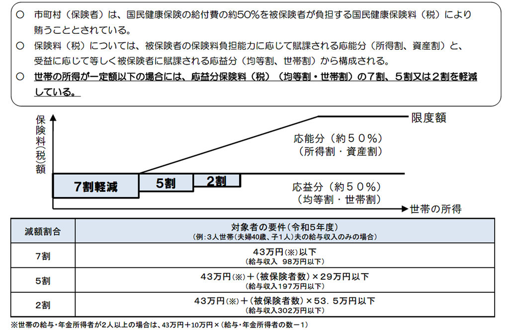

軽減措置

### 被用者の健康保険組合・協会けんぽ

協会けんぽは主に中小企業、健保組合は主に大企業の被用者が加入する。 労使折半前の保険料は、健保組合の方がやや低い？

都道府県単位で決まっているのは協会けんぽである。 ここでは、被用者は全員が、各都道府県の協会けんぽに加入しているという仮定をしている。

[協会けんぽの都道府県別保険料率](https://www.kyoukaikenpo.or.jp/g7/cat330/sb3150/r06/r6ryougakuhyou3gatukara/)

`R/kyokai_kenpo.R`で元データの加工を行った。

```r
kenpo_table <- read_csv(
    here("data/kyokai_kenpo/premiums.csv"),
    show_col_types = FALSE
    )
```

```r
calc_kenpo <- function(person) {

  income <- person$income_earned
  pref <- person$pref

  income_month <- income / 12 # 年収を月当たりに
  unit <- 1e4
  data <- kenpo_table |>
    filter(
      (is.na(Lower) | Lower <= income_month * unit),
      (is.na(Upper) | Upper > income_month * unit),
      Pref == pref
    ) |>
    select(`保険料_介護保険2号該当_全額`) # 全額とする
    # select(`保険料_介護保険2号該当_折半額`) # 全額ではなく折半額とする

  as.double(data) * 12 / unit # 年間の合計額、万円単位に
}
```

```r
calc_kenpo(psn_employed)
```

```
[1] 23.2152
```

## 控除

### 青色・白色申告控除

国税庁「[青色申告特別控除](https://www.nta.go.jp/taxes/shiraberu/taxanswer/shotoku/2072.htm)」

所得税の算出に際して、不動産所得あるいは事業所得を営んでいる者のうち、一定の条件を満たした者は、最大で65万円の所得控除を受けることができる。

```r
deduct_blue_tax_ret <- function(person) {
  if (person$is_blue_tax == TRUE) {
    d <- 65
  } else {
    d <- 0
  }

  return(d)
}
```

```r
deduct_blue_tax_ret(psn_gig)
```

```
[1] 65
```

### 社会保険料控除

```r
deduct_insur <- function(person) {

  income <- person$income_earned
  nat_or_emp <- person$pension

  ## 年金保険料
  pension <- calc_pension(person)

  ## 国民健康保険料
  kokuho <- calc_kokuho(person)

  ## 協会けんぽ保険料
  kenpo <- calc_kenpo(person)

  ## 結果
  if (nat_or_emp == "nat") {
    result <- sum(pension, kokuho)
  } else if (nat_or_emp == "emp") {
    result <- sum(pension, kenpo)
  }

  result
}
```

例：

```r
deduct_insur(psn_employed)
```

```
[1] 60.5472
```

## 課税所得額を算出する関数 完了

```r
## tax引数は、所得税か住民税かの違い
get_taxable <- function(person) {

  ## 控除 -----------------------

  ## earned incomeから、控除額を差し引く = taxable income --------------
  ## 今回のモデルでは、入口はincome_earnedだけなので、
  ## income_taxableが合計所得金額＝総所得金額等になる
  income_taxable <- person$income_earned - deduct_basic(person) - deduct_insur(person) - deduct_blue_tax_ret(person)

  ## 給与所得を得ている人の場合に、給与所得控除を適用する --------------
  if (person$is_salary == TRUE) {
    income_taxable <- income_taxable - deduct_income(person)
  }

  income_taxable <- income_taxable |>
    ## 課税所得額が負になることを防ぐ ------------------------------------
    mutate(across(where(is.numeric), \(x) pmax(x, 0))) |>
    ## 1,000円未満の端数金額を切り捨てた後の金額を返す -------------------
    mutate(across(where(is.numeric), \(x) floor(x * 1e4 / 1e3) * 1e3 / 1e4)) |>
    rename(
      taxable_income = basic_ded_income,
      taxable_resid = basic_ded_resid
    )

  income_taxable
}
```

```r
get_taxable(psn_gig)
```

| taxable_income | taxable_resid |
| --- | --- |
| 41.9 | 46.9 |

## 所得税 完了

所得税額 = `taxable income * tax rate`

earned incomeから、課税される所得金額（1,000円未満の端数金額を切り捨てた後の金額）に対する所得税の金額を算出する関数を用意する。

- [国税庁, 所得税の税率](https://www.nta.go.jp/taxes/shiraberu/taxanswer/shotoku/2260.htm)
- [財務省「所得税の税率構造」](https://www.mof.go.jp/tax_policy/summary/income/b02.htm)

```r
## 引数のincomeは、万円単位のtaxable incomeである
## numは、扶養家族人数
calc_tax_income <- function(person) {

  taxable <- get_taxable(person)$taxable_income

  ## 課税所得金額のボーダー
  b1 <- 0.1
  b2 <- 195
  b3 <- 330
  b4 <- 695
  b5 <- 900
  b6 <- 1800
  b7 <- 4000

  ## rは税率、dは控除額
  if (taxable <= 0) {
    result <- 0
    return(result)
  } else if (taxable >= b1 & taxable < b2) {
    r <- 0.05
    d <- 0
  } else if (taxable >= b2 & taxable < b3) {
    r <- 0.1
    d <- 9.75
  } else if (taxable >= b3 & taxable < b4) {
    r <- 0.2
    d <- 42.75
  } else if (taxable >= b4 & taxable < b5) {
    r <- 0.23
    d <- 63.6
  } else if (taxable >= b5 & taxable < b6) {
    r <- 0.33
    d <- 153.6
  } else if (taxable >= b6 & taxable < b7) {
    r <- 0.4
    d <- 279.6
  } else if (taxable >= b7) {
    r <- 0.45
    d <- 479.6
  }

  income_tax <- (taxable * r) - d

  ## 「所得税等」の額の計算
  ## 定額減税
  ## 本人分（３万円）と同一生計配偶者及び扶養親族分（１人につき３万円）の合計額
  # if (taxable <= 1805) {
  #   income_tax <- income_tax - 3 * num
  # }

  ## 復興特別所得税は所得税額の2.1%
  ## 結果は100円未満切り捨て
  income_tax <- floor((income_tax + income_tax * 0.021) * 1e2) / 1e2

  ## 所得税額が負になっていたら、0とする
  if (income_tax < 0) {
    0
  } else {
    income_tax
  }
}
```

例：さいたま市在住の被用者の場合の所得税額

```r
calc_tax_income(psn_employed)
```

```
[1] 1.19
```

## 住民税 完了

市民税＋県民税を住民税と呼ぶ。

前年の所得に応じた「所得割」と、一定の所得がある人が負担する「均等割」がある。

- 所得割は、一律10％で課される。
- 均等割は、3500円/人 (市民税) + 1500円/人 (県民税)が課される。
- [財務省「個人所得課税の税率等の推移（イメージ図）」](https://www.mof.go.jp/tax_policy/summary/income/b02.htm)

住民税の算出方法は、次を参考にした: https://www.cr.mufg.jp/mycard/knowledge/23031/index.html

```r
calc_tax_resident <- function(person) {

  taxable <- get_taxable(person)$taxable_resid
  num <- person$num

  ## 所得割額を算出（税額控除はないものとする）
  tax_rate <- 0.1 # 0.1は標準税率で、自治体によって異なりうるが、基本は10％
  tax <- taxable * tax_rate
  tax <- trunc(tax * 1e2) / 1e2 # 100円未満切り捨ての処理

  ## 調整控除を差し引く
  ## 調整控除額は、今のところ、基礎控除の差を使っている
  ## https://www.city.saitama.lg.jp/001/153/004/002/001/004/p013670.html
  diff <- 48 - 43
  if (taxable <= 200) {
    ## 人的控除額の差の合計額か、合計課税所得金額のうち少ない金額の5％を控除する
    if (taxable < diff) {
      ded <- taxable * 0.05
    } else {
      ## 人的控除額 = ここでは基礎控除の差額に、5％を乗じて、それを税額控除する
      ded <- diff * 0.05
    }
  } else if (taxable > 200 & taxable <= 2500) {
    ## {人的控除額の差の合計額－（合計課税所得金額－200万円）}の5％（市民税4％、県民税1％）に相当する金額
    ded <- (diff - (taxable - 200)) * 0.05
  } else if (taxable > 2500) {
    ded <- 0
  }

  ## ただし、この金額が2,500円未満の場合は、2,500円（市民税2,000円、県民税500円）とします。
  if (ded < 0.25) {
    ded <- 0.25
  }

  tax <- tax - ded

  ## 均等割
  eq <- 0.35 + 0.15

  ## 森林環境税
  if ((taxable < 41.5 & num == 1) | (num >= 2 & taxable < 31.5 * num + 10 + 18.9)) {
    forest <- 0
  } else {
    forest <- 0.1
  }

  ## 非課税世帯の処理 ------------------
  if ((num == 1 & taxable <= 45) | (num >= 2 & taxable <= 35 * num + 31)) {
    ## 所得割・均等割が非課税
    tax <- 0
    eq <- 0
  } else if ((num == 1 & taxable < 45) | (num >= 2 & taxable < 35 * num + 42)) {
    ## 所得割が非課税
    tax <- 0
  }

  ## 均等割額＋森林環境税を加算
  resident_tax <- tax + eq + forest

  ## 定額減税適用（2024年6月～2025年5月適用）
  ## 本人分（1万円）と同一生計配偶者及び扶養親族分（1人につき1万円）の合計額
  # if (taxable <= 1805) {
  #   resident_tax <- resident_tax - 1 * num
  # }

  if (resident_tax < 0) {
    return(0)
  } else {
    resident_tax
  }
}
```

```r
calc_tax_resident(psn_gig)
```

```
[1] 5.04
```

```r
#calc_pension_emp(300, monthly_premiums) + calc_kokuho(300, 1, saitama)
```

```r
## たくさんのpersonオブジェクト
persons <- psn_employed |>
  mutate(income_earned = list(seq(100, 500, 20))) |>
  unnest(income_earned)
```

## 消費税

earned incomeの何割を消費に当てると仮定するか？ これは、税・社会保険料を除く全てを消費するものと仮定する。

```r
calc_vat <- function(person) {
  ## earned incomeごとの税・社会保険料の合計値を得たい
  ## 所得税
  tax_income <- calc_tax_income(person)
  ## 住民税
  tax_resit <- calc_tax_resident(person)


  nat_or_emp <- person$pension
  ## 健康保険
  if (nat_or_emp == "nat") {
    insurance <- calc_kokuho(person)
  } else if (nat_or_emp == "emp") {
    insurance <- calc_kenpo(person)
  }

  ## 年金
  pension <- calc_pension(person)

  ## 税・社会保険料の合計額
  total <- sum(tax_income, tax_resit, insurance, pension)

  ## 消費税は、income_earned から税・社会保険料を除いた全額に掛かると考える
  tax_rate <- 0.1 # 消費税率を10％とした
  consume <- person$income_earned - total # 消費額
  vat <- consume * tax_rate

  if (vat < 0) {
    vat <- 0
  }
  vat
}
```

```r
calc_vat(psn_employed)
```

```
[1] 13.82628
```

## 図：税額・保険料額を合計する

```r
calc_tax_and_prem <- function(person) {

  #print(paste("Earned income:", person$income_earned))

  income <- person$income_earned

  ## 課税所得額
  taxable_income <- get_taxable(person)$taxable_income
  taxable_resid <- get_taxable(person)$taxable_resid

  ## 年金・健康保険
  nat_or_emp <- person$pension
  pension <- calc_pension(person)
  if (nat_or_emp == "nat") {
    ## 自営業者
    insurance <- calc_kokuho(person)
    #print(paste0("国民年金保険料: ", pension))
    #print(paste("国民健康保険料:", insurance))
  } else if (nat_or_emp == "emp") {
    ## 被用者
    insurance <- calc_kenpo(person)
    #print(paste0("厚生年金保険料: ", pension))
    #print(paste("被用者健康保険料:", insurance))
  }

  ## 住民税
  resident <- calc_tax_resident(person)
  #print(paste0("住民税: ", resident))

  ## 所得税
  income_tax <- calc_tax_income(person)
  #print(paste("所得税:", income_tax))

  ## 消費税
  vat <- calc_vat(person)
  #print(paste("消費税:", vat))

  ## 合計
  total <- sum(insurance, pension, resident, income_tax, vat)
  #print(paste("税・社会保険料の合計:", total))

  ## 結果のtibble
  result <- tibble(
    `年収` = income,
    `課税所得 (所得税)` = taxable_income,
    `課税所得 (住民税)` = taxable_resid,
    `年金` = pension,
    `健康保険` = insurance,
    `住民税` = resident,
    `所得税` = income_tax,
    `消費税` = vat,
    `負担合計` = total,
    `手取り額` = income - (pension + insurance + resident + income_tax),
    `年収に占める所得・住民税の百分率` = ((income_tax + resident) / person$income_earned) * 100
  )

  return(result)
}
```

### 自営業者の場合

埼玉県さいたま市在住の40歳単身世帯をモデルとした。 年金は国民年金に、健康保険は国民健康保険に加入しているものとする。 所得税額の算出に際しては、定額減税は加えていない。 消費税額は、年収から所得税・住民税・社会保険料負担を差し引いた全額を消費すると仮定し、税率10％を乗じて算出した。

青色申告者 (`psn_gig`) と白色申告者 (`psn_gig_white`) の2つを考える。

#### 青色申告者の場合：

```r
result_gig <- calc_tax_and_prem(psn_gig)
result_gig
```

| 年収 | 課税所得 (所得税) | 課税所得 (住民税) | 年金 | 健康保険 | 住民税 | 所得税 | 消費税 | 負担合計 | 手取り額 | 年収に占める所得・住民税の百分率 |
| --- | --- | --- | --- | --- | --- | --- | --- | --- | --- | --- |
| 200 | 41.9 | 46.9 | 20.376 | 24.65 | 5.04 | 2.13 | 14.7804 | 66.9764 | 147.804 | 3.585 |

```r
result_gig_write <- result_gig |> pivot_longer(cols = everything()) |>
  mutate(across(where(is_double), \(x) round(x, 4)))
write_excel_csv(result_gig_write, here("data/psn_gig_200.csv"))
```

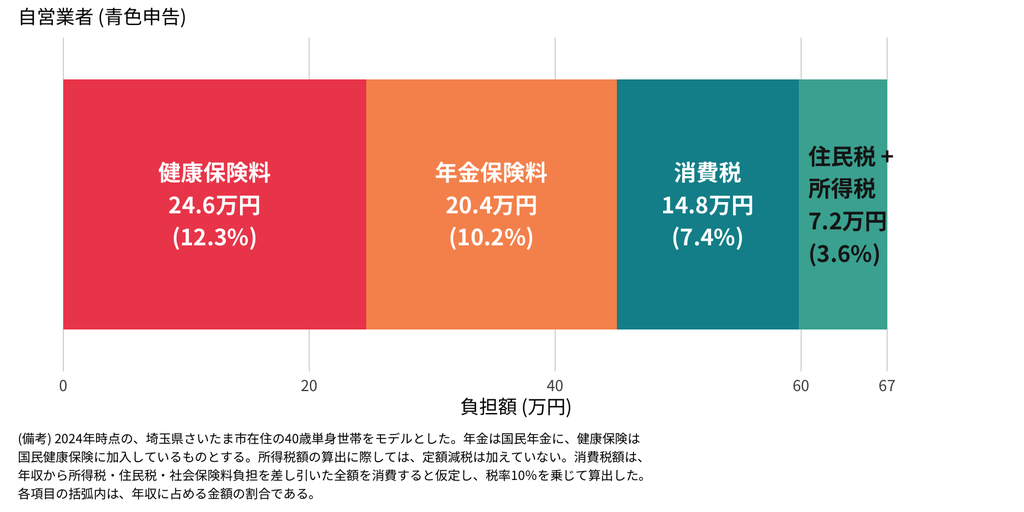

```r
source("R/figure_gig.R")
(fig_gig <- make_fig_gig(result_gig) +
  labs(
    subtitle = "自営業者 (青色申告)",
    caption = str_wrap("(備考) 2024年時点の、埼玉県さいたま市在住の40歳単身世帯をモデルとした。年金は国民年金に、健康保険は国民健康保険に加入しているものとする。所得税額の算出に際しては、定額減税は加えていない。消費税額は、年収から所得税・住民税・社会保険料負担を差し引いた全額を消費すると仮定し、税率10％を乗じて算出した。各項目の括弧内は、年収に占める金額の割合である。", width = 100, whitespace_only = FALSE)
    )
  )
```

```r
save_fig_gig("psn_gig_200.png", fig_gig)
```

#### 白色申告者の場合：

```r
## 白色申告者
psn_gig_white <- person(
  200, saitama, "埼玉", FALSE, FALSE, "nat", 1
  )

fig_gig_white <- calc_tax_and_prem(psn_gig_white) |>
  make_fig_gig() +
  labs(
    subtitle = "自営業者 (白色申告)",
    caption = str_wrap("(備考) 2024年時点の、埼玉県さいたま市在住の40歳単身世帯をモデルとした。年金は国民年金に、健康保険は国民健康保険に加入しているものとする。所得税額の算出に際しては、定額減税は加えていない。消費税額は、年収から所得税・住民税・社会保険料負担を差し引いた全額を消費すると仮定し、税率10％を乗じて算出した。各項目の括弧内は、年収に占める金額の割合である。", width = 100, whitespace_only = FALSE)
    )
save_fig_gig("psn_gig_200_white.png", fig_gig_white)
```

### 給与所得者の場合

- 埼玉県さいたま市在住の40歳単身世帯をモデルとした。
- 年金は厚生年金に、健康保険は都道府県の協会けんぽに加入しているものとする。
- 所得税額の算出に際しては、定額減税は加えていない。
- 消費税額は、年収から所得税・住民税・社会保険料負担を差し引いた全額を消費すると仮定し、税率10％を乗じて算出した。

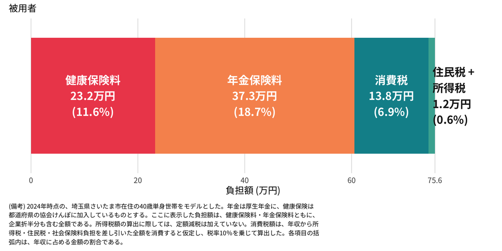

```r
psn_salary200 <- person(200, saitama, "埼玉", TRUE, FALSE, "emp", 1)
source("R/figure_gig.R")
result_salary200 <- calc_tax_and_prem(psn_salary200)
(fig_salary200 <- make_fig_gig(result_salary200) +
    labs(
      subtitle = "被用者",
      caption = str_wrap("(備考) 2024年時点の、埼玉県さいたま市在住の40歳単身世帯をモデルとした。年金は厚生年金に、健康保険は都道府県の協会けんぽに加入しているものとする。ここに表示した負担額は、健康保険料・年金保険料ともに、企業折半分も含む全額である。所得税額の算出に際しては、定額減税は加えていない。消費税額は、年収から所得税・住民税・社会保険料負担を差し引いた全額を消費すると仮定し、税率10％を乗じて算出した。各項目の括弧内は、年収に占める金額の割合である。", width = 100, whitespace_only = FALSE)
      )
  )
```

```r
save_fig_gig("psn_salary200.png", fig_salary200, height = 85)
```

自営・被用者のグラフの比較図

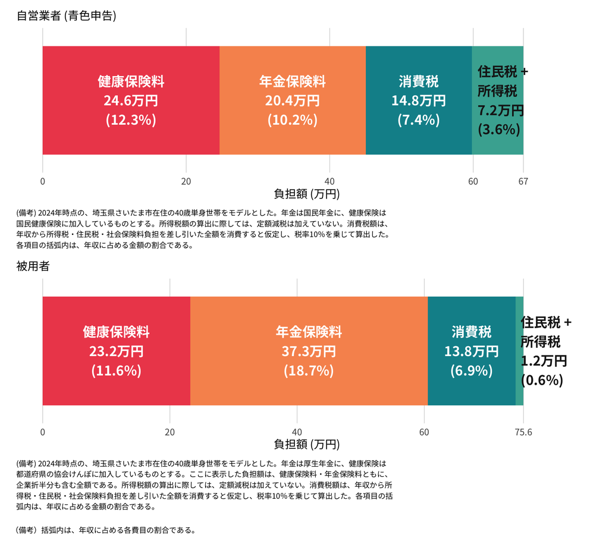

```r
(psn_gig_salary <- fig_gig / fig_salary200 +
   patchwork::plot_annotation(
     caption = "（備考）括弧内は、年収に占める各費目の割合である。"
   ))
```

```r
save_fig_gig("psn_gig_salary.png", psn_gig_salary, width = 200, height = 140)
```

## 資料

- [家族と税](https://www.nta.go.jp/publication/pamph/koho/kurashi/html/02_2.htm)
  - 扶養控除などの話はここに書いてある
- [何万円以上収入があると税金が課税されるのでしょうか。](https://www.city.chiba.jp/faq/zaiseikyoku/zeimu/kazeikanri/127.html)
- [所得税と住民税の控除額の分離案](https://www.sankei.com/article/20241129-U5GUEPKVYJE7DHIRI3VAPCLCIU/)

## 脚注の文章

課税所得と所得の違いについて。

- 自営業者の場合、収入（売上）から必要経費を引いたものが所得金額であり、その所得金額から基礎控除や社会保険料控除などの所得控除額を引いたものが、課税所得金額である。
- 給与所得者の場合、給与収入から給与所得控除を差し引いたものが所得金額であり、その所得金額から基礎控除や社会保険料控除などの所得控除額を引いたものが、課税所得金額である。

所得税の申告納税額については、[国税庁「所得税のしくみ」](https://www.nta.go.jp/publication/pamph/koho/kurashi/html/01_1.htm)を参照している。